# From Data To Decisions

Modern Data Analysis with R

Dwight Wynne

December 2, 2017

# Goals of This Workshop

- Understand the six-step modeling process, how each step works, and why each step is important
- Learn powerful techniques for analyzing and modeling data and understand why they work
- Write code to start implementing models in R

# How This Workshop Works

Within each module you can expect:

- Theory: what and why
- Example code you can copy
- Activities where you write your own code (using the example as a template)

I expect you to have some struggles with the activities! Work with people around you to tackle the problem, and ask me for help!

# What is Statistical Learning?

- Any technique used for understanding data
- **Supervised** statistical learning: we want to understand relationships between one or more inputs and a clear *output* variable
- **Unsupervised** statistical learning: we want to understand relationships between multiple variables, but there is no clear output

# Statistical Learning: Model Assumptions

- *Parametric* techniques assume specific mathematical relationships between the variables
- *Nonparametric* techniques make no assumptions about those mathematical relationships

# Statistical Learning: Goals

- *Regression* techniques predict a numerical output from one or more inputs
- *Classification* techniques predict a category from one or more inputs
- Both regression and classification techniques can use any kind of variable as an *input*

# The Number 1 Question You Must Ask Before You Start Modeling

### Who Are You Modeling For?

# Trade-off 1: Accuracy vs. Interpretability

- Which is more important:
  - Getting the right answer?
  - Explaining how you got that answer?

# Trade-off 2: Bias vs. Variance

- Your model will be off. Would you rather it be…
  - Consistently over- or under-estimating your data?
  - Accurate, on average, but all over the place?

# Trade-off 3: Current vs. Future Data

- Which is more important to get right:
  - Explaining current observations?
  - Predicting future observations?

# Statistical Answers to Trade-offs

- Techniques vary in their interpretability, but statisticians *penalize complexity* to find the simplest model that will work
- Statisticians reduce the *total amount* of error, and don’t care if they have to trade an increase in bias for a decrease in variance (or vice versa)
- Statisticians always watch for *overfitting* randomness in the current data and typically evaluate techniques based on their ability to predict future data

# The Data to Decisions Pipeline

- In order to make informed decisions, we have to answer two questions:
  - What is happening?
  - What is going to happen?
- We *must* answer the first question before we can even attempt to answer the second

# The Six-Step Modeling Process

### Background Analysis

- What data do I have? What do the variables mean? What values do they take?

### Exploratory Analysis

- What are the main features of my data set? How do those features interact? Is there anything unexpected?

### Feature Selection

- What do I want to predict? What features will help me make that prediction, and which appear to be irrelevant?

# The Six-Step Modeling Process

### Model Building

- What kind of model is appropriate to use to predict an outcome? How should I combine the features to make the prediction?

### Model Validation

- Which of the models I made in the previous step is best?

### Model Interpretation

- What outcomes does this model suggest will happen for future observations? How do I interpret the effect of each feature in a real-world context? What does this suggest about my decisions?

# Introduction to R Studio

- R is a combination statistical software and specialized programming language
- R Studio makes it easier to do data analysis with R by automating many non-coding aspects of data analysis
- Commands are run in the Console window
- To make coding easier, write code in a script, then highlight it and click Run
- Click $File \rightarrow New File \rightarrow R \ Script \$to open a new R script

# Basics of R Coding

- Basic arithmetic operations can be typed in directly
- More complex functions are called using the syntax `function(arguments)`
- The assignment operator (`<-`) creates a new variable
- The concatenate function (`c()`) creates a vector

```r
a <- c(2, 4, 6)
b <- sqrt(a)
print(b)
```

```
## [1] 1.414214 2.000000 2.449490
```

# Basics of R Coding

Important Notes:

- The square root function is applied to every element in the vector `a`
- When we store a variable, nothing is output to the Console
- To show a variable’s value in the Console, use the command `print(variable)`
- We can also look up the variable in the *Environment* tab

# R Syntax and Debugging: Tips

- When you start out you will forget the name of functions or arguments! This is okay and expected!
- When you get good at coding you will still forget the name of functions and arguments!

# R Syntax and Debugging: Tips

- When you start out you will forget the name of functions or arguments! This is okay and expected!
- When you get good at coding you will still forget the name of functions and arguments!
- When you start out you will make a lot of typos! This is okay and expected!
- When you get good at coding you will make even more typos! You just won’t take as long to figure out the error!
- Write everything in a Script, highlight what you want to run, and click `Run`. Then you can fix the error and run it again, instead of messing around in the Console. This will save you uncountably many hours fixing your typos.

# R Syntax and Debugging: Tips

- If you get an error message, something’s wrong. If you get a warning message, you’re probably okay.
- If you get an error message, check the following:
  - Did you capitalize correctly?
  - Does every left parenthesis have a matching right one () in the correct place?
  - Does every quotation mark have a matching one “” at the end of the quote?
  - R Studio thinks it’s being helpful by automatically adding the second parenthesis/quotation mark, but it isn’t!
- Google is your friend: many people have gotten similarly arcane error messages

# Introduction to the tidyverse

- R is extended by thousands of *packages* that perform specific statistical and analytical functions
- The *tidyverse* is a set of packages designed to make working with data easy

```r
library(tidyverse)
```

# Importing Data

- Click the `Import Dataset` button in the `Environment` window and select “From CSV…”
- Other formats (e.g. Excel) are also supported natively by the tidyverse
- Find your data file
- Name your file in the *Name* box
- Click `Import`
- There are many options for getting your data to import correctly

# Background Analysis Activity

View your dataset. For example, I call my dataset `APR`, so I would type:

```r
View(APR)
```

in the script, and then highlight it and click the `Run` button.

Figure out what the following variables represent:

- `SCL_NAME`
- `SCL_HBCU`
- `SCL_PRIVATE`
- `NUM_OF_ATHLETES_2014`

# Manipulating Data with dplyr

There are five main objectives of data manipulation:

- Select specific observations (`filter()`)
- Select specific variables (`select()`)
- Sort observations based on the value of a variable (`arrange()`)
- Create new variables based on existing variables (`mutate()`)
- Summarize the values of a variable (`summarize()`)

# The Pipe Operator

The `dplyr` library includes a “pipe” operator (`%>%`) that makes code more understandable. The pipe operator means:

- Take the data frame on the left side of the pipe
- Perform the command on the right side of the pipe

# Selecting Observations

```r
# Select FBS universities

APR %>% filter(SUBDIVISION == 1)
```

```
## # A tibble: 124 × 21
##    SCL_ID                             SCL_NAME SUBDIVISION
##     <int>                                <chr>       <int>
## 1  100751                University of Alabama           1
## 2  100858                    Auburn University           1
## 3  102094          University of South Alabama           1
## 4  102368                      Troy University           1
## 5  104151             Arizona State University           1
## 6  104179                University of Arizona           1
## 7  106397 University of Arkansas, Fayetteville           1
## 8  106458            Arkansas State University           1
## 9  110556  California State University, Fresno           1
## 10 110635   University of California, Berkeley           1
## # ... with 114 more rows, and 18 more variables: CONFERENCE <chr>,
## #   SCL_HBCU <int>, SCL_PRIVATE <int>, APR_2014 <int>,
## #   ELIG_RATE_2014 <dbl>, RET_RATE_2014 <dbl>, NUM_OF_ATHLETES_2014 <int>,
## #   APR_2013 <int>, ELIG_RATE_2013 <dbl>, RET_RATE_2013 <dbl>,
## #   NUM_OF_ATHLETES_2013 <int>, APR_2012 <int>, ELIG_RATE_2012 <dbl>,
## #   RET_RATE_2012 <dbl>, NUM_OF_ATHLETES_2012 <int>, PUB_AWARD_15 <int>,
## #   PUB_AWARD_14 <int>, PUB_AWARD_13 <int>
```

# Using Multiple Criteria

```r
# Select public schools in Pac-12
APR %>% filter(SCL_PRIVATE == 0, CONFERENCE == "Pac-12 Conference")
```

```
## # A tibble: 10 × 21
##    SCL_ID                              SCL_NAME SUBDIVISION
##     <int>                                 <chr>       <int>
## 1  104151              Arizona State University           1
## 2  104179                 University of Arizona           1
## 3  110635    University of California, Berkeley           1
## 4  110662 University of California, Los Angeles           1
## 5  126614       University of Colorado, Boulder           1
## 6  209542               Oregon State University           1
## 7  209551                  University of Oregon           1
## 8  230764                    University of Utah           1
## 9  236939           Washington State University           1
## 10 236948              University of Washington           1
## # ... with 18 more variables: CONFERENCE <chr>, SCL_HBCU <int>,
## #   SCL_PRIVATE <int>, APR_2014 <int>, ELIG_RATE_2014 <dbl>,
## #   RET_RATE_2014 <dbl>, NUM_OF_ATHLETES_2014 <int>, APR_2013 <int>,
## #   ELIG_RATE_2013 <dbl>, RET_RATE_2013 <dbl>, NUM_OF_ATHLETES_2013 <int>,
## #   APR_2012 <int>, ELIG_RATE_2012 <dbl>, RET_RATE_2012 <dbl>,
## #   NUM_OF_ATHLETES_2012 <int>, PUB_AWARD_15 <int>, PUB_AWARD_14 <int>,
## #   PUB_AWARD_13 <int>
```

# Filtering Out Observations

```r
# Filter out SEC
APR %>% filter(CONFERENCE != "Southeastern Conference")
```

```
## # A tibble: 233 × 21
##    SCL_ID                           SCL_NAME SUBDIVISION
##     <int>                              <chr>       <int>
## 1  100654             Alabama A&M University           2
## 2  100724           Alabama State University           2
## 3  101480      Jacksonville State University           2
## 4  102049                 Samford University           2
## 5  102094        University of South Alabama           1
## 6  102368                    Troy University           1
## 7  104151           Arizona State University           1
## 8  104179              University of Arizona           1
## 9  105330        Northern Arizona University           2
## 10 106412 University of Arkansas, Pine Bluff           2
## # ... with 223 more rows, and 18 more variables: CONFERENCE <chr>,
## #   SCL_HBCU <int>, SCL_PRIVATE <int>, APR_2014 <int>,
## #   ELIG_RATE_2014 <dbl>, RET_RATE_2014 <dbl>, NUM_OF_ATHLETES_2014 <int>,
## #   APR_2013 <int>, ELIG_RATE_2013 <dbl>, RET_RATE_2013 <dbl>,
## #   NUM_OF_ATHLETES_2013 <int>, APR_2012 <int>, ELIG_RATE_2012 <dbl>,
## #   RET_RATE_2012 <dbl>, NUM_OF_ATHLETES_2012 <int>, PUB_AWARD_15 <int>,
## #   PUB_AWARD_14 <int>, PUB_AWARD_13 <int>
```

# Selecting Variables

```r
APR %>% select(SCL_NAME, APR_2014)
```

```
## # A tibble: 247 × 2
##                         SCL_NAME APR_2014
##                            <chr>    <int>
## 1         Alabama A&M University      905
## 2       Alabama State University      902
## 3          University of Alabama     1000
## 4              Auburn University      985
## 5  Jacksonville State University      965
## 6             Samford University      993
## 7    University of South Alabama      960
## 8                Troy University      938
## 9       Arizona State University      964
## 10         University of Arizona      943
## # ... with 237 more rows
```

# Sorting Observations in Ascending Order (A-Z)

```r
# Sort ascending by conference name
APR %>% arrange(CONFERENCE) %>% select(SCL_NAME, CONFERENCE)
```

```
## # A tibble: 247 × 2
##                         SCL_NAME                   CONFERENCE
##                            <chr>                        <chr>
## 1      University of Connecticut American Athletic Conference
## 2  University of Central Florida American Athletic Conference
## 3    University of South Florida American Athletic Conference
## 4              Tulane University American Athletic Conference
## 5       East Carolina University American Athletic Conference
## 6       University of Cincinnati American Athletic Conference
## 7        The University of Tulsa American Athletic Conference
## 8              Temple University American Athletic Conference
## 9          University of Memphis American Athletic Conference
## 10         University of Houston American Athletic Conference
## # ... with 237 more rows
```

# Sorting Observations in Descending Order (Z-A)

```r
# Sort descending by APR
APR %>% arrange(desc(APR_2014)) %>% select(SCL_NAME, APR_2014)
```

```
## # A tibble: 247 × 2
##                             SCL_NAME APR_2014
##                                <chr>    <int>
## 1              University of Alabama     1000
## 2                  Mercer University     1000
## 3  University of Illinois, Champaign     1000
## 4             University of Michigan     1000
## 5        University of New Hampshire     1000
## 6   University of Wisconsin, Madison     1000
## 7                  Dartmouth College      998
## 8          College of the Holy Cross      996
## 9                  Lafayette College      996
## 10                  Drake University      995
## # ... with 237 more rows
```

# Sorting Using Multiple Criteria

```r
# Sort by conference, then by APR
APR %>% arrange(CONFERENCE, desc(APR_2014)) %>% select(SCL_NAME, APR_2014, CONFERENCE)
```

```
## # A tibble: 247 × 3
##                         SCL_NAME APR_2014                   CONFERENCE
##                            <chr>    <int>                        <chr>
## 1              Tulane University      988 American Athletic Conference
## 2              Temple University      979 American Athletic Conference
## 3       University of Cincinnati      978 American Athletic Conference
## 4       East Carolina University      977 American Athletic Conference
## 5  University of Central Florida      973 American Athletic Conference
## 6      University of Connecticut      970 American Athletic Conference
## 7    University of South Florida      954 American Athletic Conference
## 8          University of Memphis      950 American Athletic Conference
## 9        The University of Tulsa      939 American Athletic Conference
## 10         University of Houston      937 American Athletic Conference
## # ... with 237 more rows
```

# Creating New Variables

```r
# Eligibility and retention rate in Percent
APR %>% mutate(ELIG_PCT = ELIG_RATE_2014 * 100, RET_PCT = RET_RATE_2014 * 100) %>%
    select(SCL_NAME, ELIG_PCT, RET_PCT)
```

```
## # A tibble: 247 × 3
##                         SCL_NAME  ELIG_PCT  RET_PCT
##                            <chr>     <dbl>    <dbl>
## 1         Alabama A&M University  81.08108 97.97297
## 2       Alabama State University  87.96992 92.48120
## 3          University of Alabama 100.00000 98.73418
## 4              Auburn University  98.80240 98.17073
## 5  Jacksonville State University  96.83544 94.23077
## 6             Samford University  99.31507 99.31034
## 7    University of South Alabama  95.67901 95.65217
## 8                Troy University  94.11765 93.45238
## 9       Arizona State University  96.07843 94.70199
## 10         University of Arizona  92.81437 95.15152
## # ... with 237 more rows
```

# Summarizing Variables

```r
APR %>% summarize(count = n(), mean_APR = mean(APR_2014), mean_ELIG = mean(ELIG_RATE_2014),
    mean_RET = mean(RET_RATE_2014))
```

```
## # A tibble: 1 × 4
##   count mean_APR mean_ELIG  mean_RET
##   <int>    <dbl>     <dbl>     <dbl>
## 1   247  962.247 0.9584247 0.9571375
```

# Grouping and Summarizing

- Group by the value of a variable and then summarize a numerical variable within each group

```r
APR %>% group_by(SCL_PRIVATE) %>% summarize(count = n(), mean_ELIG = mean(ELIG_RATE_2014),
    mean_RET = mean(RET_RATE_2014), mean_APR = mean(APR_2014))
```

```
## # A tibble: 2 × 5
##   SCL_PRIVATE count mean_ELIG  mean_RET mean_APR
##         <int> <int>     <dbl>     <dbl>    <dbl>
## 1           0   184 0.9541913 0.9535136 959.1033
## 2           1    63 0.9707891 0.9677216 971.4286
```

# Storing a Modified Data Set

- Just assign the result of your manipulation to a new variable:

```r
APR_new <- APR %>% filter(SCL_PRIVATE == 0, CONFERENCE == "Pac-12 Conference") %>%
    mutate(ELIG_PCT = ELIG_RATE_2014 * 100, RET_PCT = RET_RATE_2014 * 100) %>%
    select(SCL_NAME, ELIG_PCT, RET_PCT)
print(APR_new)
```

```
## # A tibble: 10 × 3
##                                 SCL_NAME ELIG_PCT  RET_PCT
##                                    <chr>    <dbl>    <dbl>
## 1               Arizona State University 96.07843 94.70199
## 2                  University of Arizona 92.81437 95.15152
## 3     University of California, Berkeley 96.87500 91.50327
## 4  University of California, Los Angeles 94.98607 94.81268
## 5        University of Colorado, Boulder 96.25000 96.85535
## 6                Oregon State University 94.61078 95.13678
## 7                   University of Oregon 98.52507 94.62687
## 8                     University of Utah 98.14815 97.41935
## 9            Washington State University 98.19277 93.82716
## 10              University of Washington 97.39884 96.47059
```

# Data Manipulation Activity

Question 1: Which private school has the lowest 2014 APR?

Question 2: Which conference has the highest average 2014 APR?

# Data Manipulation Activity

Question 1: Which private school has the lowest 2014 APR?

Question 2: Which conference has the highest average 2014 APR?

Each of these questions requires you to chain together multiple data manipulation commands with the pipe (`%>%`).

For each question, ask yourself before writing any code:

- What manipulations do I need to do to answer this question?
- What order do I need to do them in?

# Activity Solution

```r
APR %>% filter(SCL_PRIVATE == 1) %>% arrange(APR_2014) %>% select(SCL_NAME,
    APR_2014)
```

```
## # A tibble: 63 × 2
##                          SCL_NAME APR_2014
##                             <chr>    <int>
## 1               Howard University      909
## 2   Southern Methodist University      926
## 3        Robert Morris University      928
## 4              Stetson University      931
## 5  Charleston Southern University      937
## 6         The University of Tulsa      939
## 7              Liberty University      946
## 8        Brigham Young University      949
## 9                  Wagner College      950
## 10         Wake Forest University      950
## # ... with 53 more rows
```

# Activity Solution

```r
APR %>% group_by(CONFERENCE) %>% summarize(avg_APR = mean(APR_2014)) %>% arrange(desc(avg_APR))
```

```
## # A tibble: 24 × 2
##                       CONFERENCE  avg_APR
##                            <chr>    <dbl>
## 1                 The Ivy League 988.5000
## 2             Big Ten Conference 984.5000
## 3                 Patriot League 982.0000
## 4            Southern Conference 974.3750
## 5        Pioneer Football League 971.1818
## 6        Southeastern Conference 971.0000
## 7                    Independent 969.6000
## 8      Atlantic Coast Conference 968.6429
## 9  Colonial Athletic Association 968.2500
## 10       Mid-American Conference 965.1538
## # ... with 14 more rows
```

# What is Feature Selection?

- Any method designed to help include relevant variables in the model and exclude irrelevant variables
- Can be automatic based on specific criteria, or manual
- Most models don’t need more data, they need better feature selection
- Easiest way to manually select features: visualize the data

# Visualizing Data with ggplot2

Basic syntax:

- Set up a plot with the `ggplot()` command and tell it where to look for variables
- Add one or more `geom` elements to indicate what type of plot to make
- Customize the plot by adding or changing `theme` elements

Advantages of ggplot2:

- Build production-quality graphs from the ground up in an intuitive way
- Modular: save intermediate steps and fix problems one at a time
- Save “template” graphs as variables and reuse them later in the code

# Histogram Example

Suppose we want to obtain a histogram of the 2014 eligibility rates. We first set up our plot:

```r
plot1 <- ggplot(data = APR, mapping = aes(x = ELIG_RATE_2014))
```

There are three important things here:

- We start off by assigning our plot to a variable
- The `data` argument tells us where to look for the variable(s) we want
- The `aes` command tells us which variables are mapped to different axes, colors, etc.

# Histogram Example

Next, we add a histogram:

```r
plot1_hist <- plot1 + geom_histogram(center = 0.95, binwidth = 0.01)
```

The `geom_histogram` function takes two additional arguments:

- `center` is the center of one bin
- `binwidth` is the width of each bin

By specifying these arguments, we can completely specify the bins of the histogram

# Histogram Example

Finally, we add some labels and print our graph:

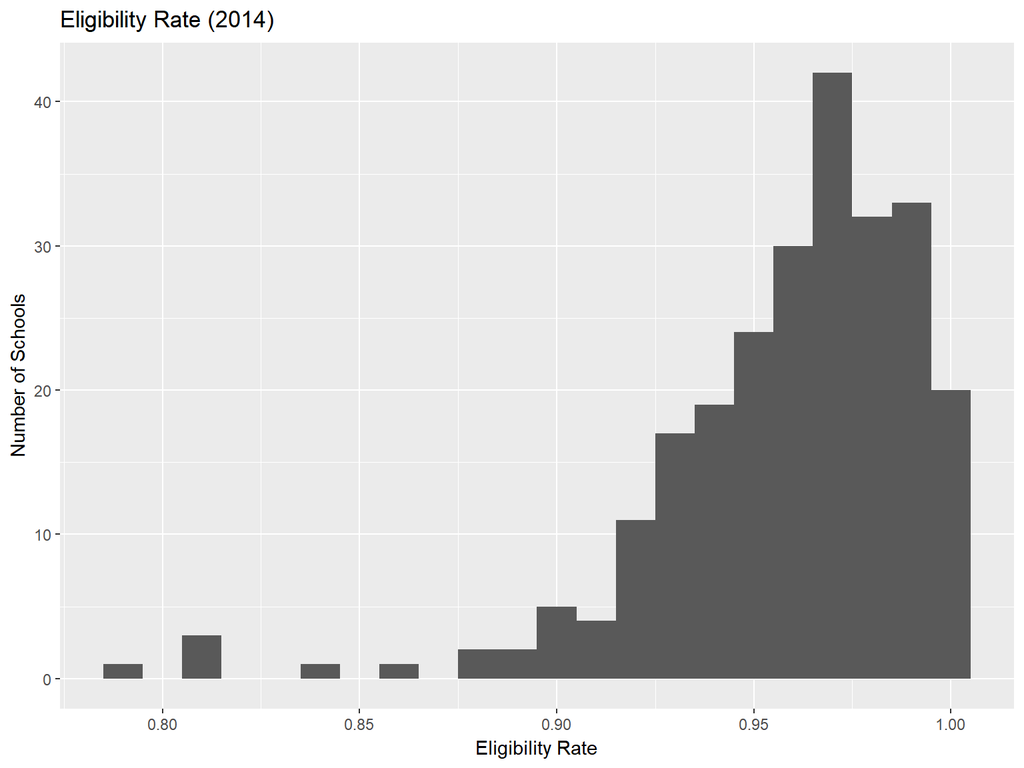

```r
plot1_labeled <- plot1_hist + labs(title = "Eligibility Rate (2014)", x = "Eligibility Rate",
    y = "Number of Schools")
print(plot1_labeled)
```

# Adding Color

Be aware that there are two kinds of color to add:

- `color` refers to the color of points on a scatterplot
- `fill` refers to the color of bars on a bar plot or histogram
- Sometimes `color` and `fill` take on other meanings depending on the `geom` you are adding

Both `color` and `fill` can take one of two types of values:

- A single color name recognized by R, such as `goldenrod`
- A variable in the data frame, indicating to use different colors for different groups

# Adding Color: Example

```r
plot1_color <- ggplot(data = APR, mapping = aes(x = ELIG_RATE_2014, fill = as.factor(SCL_PRIVATE)))
plot1_color_hist <- plot1_color + geom_histogram(center = 0.95, binwidth = 0.01)
plot1_color_labeled <- plot1_color_hist + labs(title = "Eligibility Rate (2014)",
    x = "Eligibility Rate", y = "Number of Schools")
print(plot1_color_labeled)
```

# Adding Color: Example

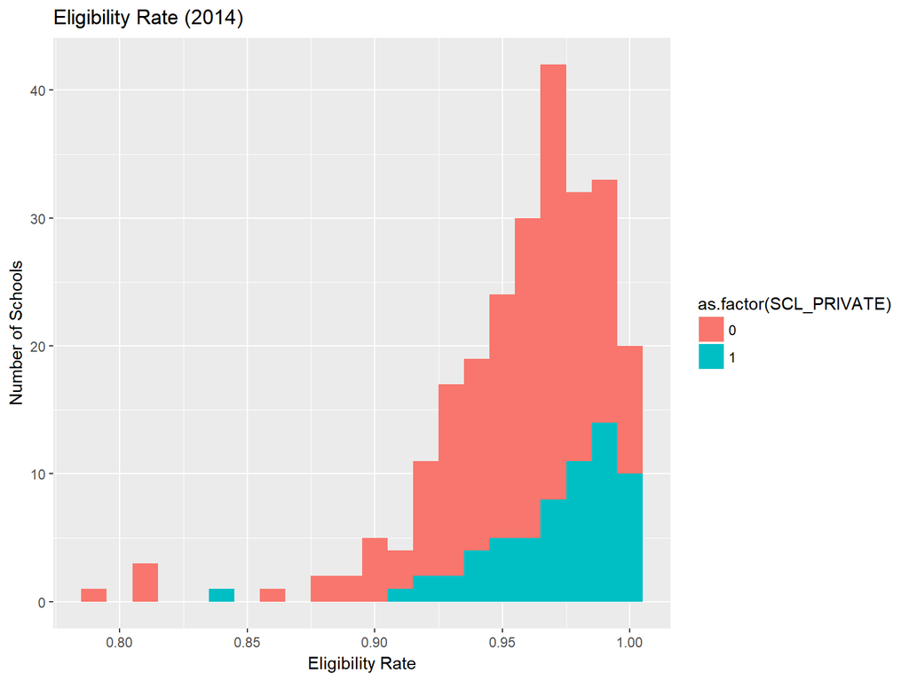

# Using Themes

This graph is not production-quality. We want to do several things:

- Get rid of the gray background
- Center the title
- Change the colors from their default settings
- Move the legend somewhere else
- Make the legend informative

All of these are done using `theme` commands. ggplot2 has several built-in themes. Two that I like are `theme_bw` and `theme_minimal`.

# Built-In Themes

`theme_bw` produces a nice black frame around the plot:

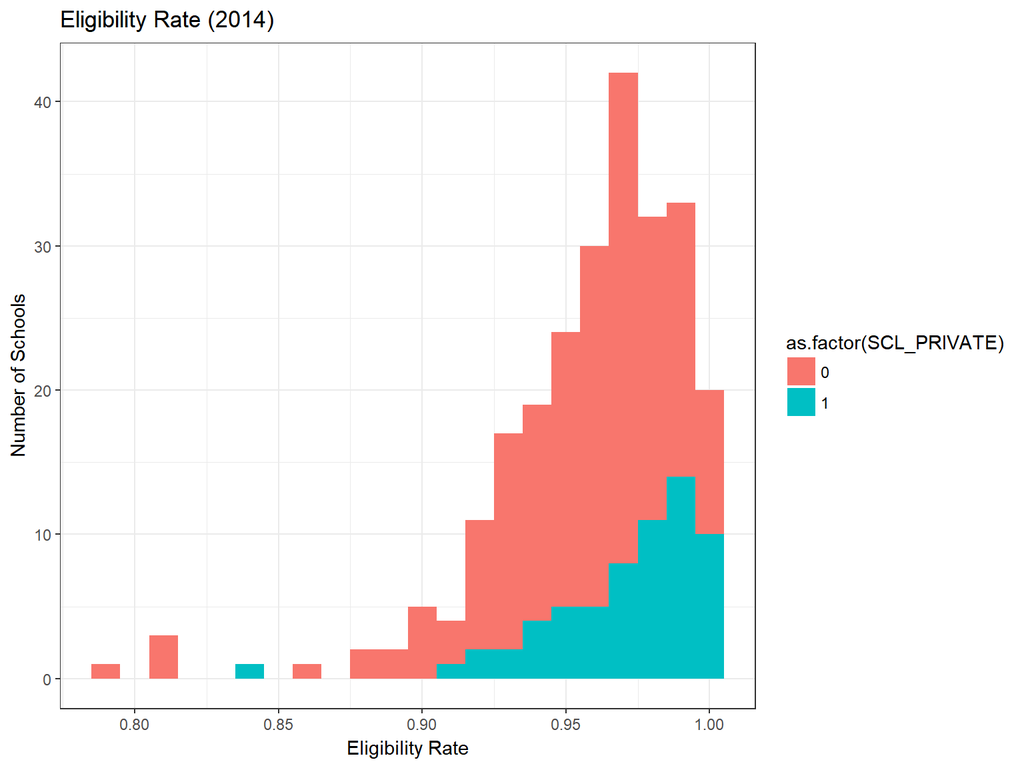

```r
plot1_bw <- plot1_color_labeled + theme_bw()
print(plot1_bw)
```

# Built-In Themes

`theme_minimal` gets rid of pretty much everything but a few gridlines:

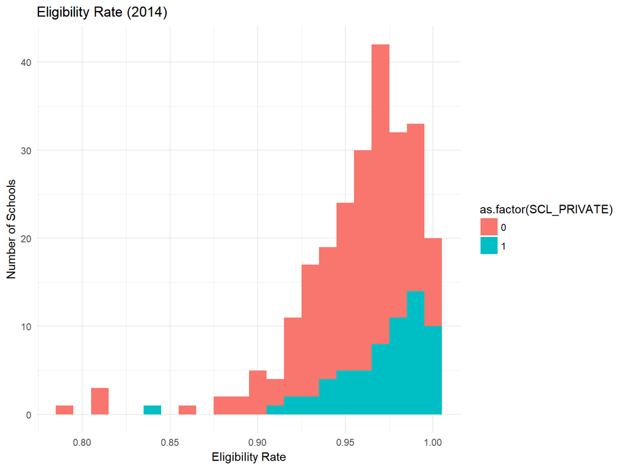

```r
plot1_minimal <- plot1_color_labeled + theme_minimal()
print(plot1_minimal)
```

# Customizing a Theme

Once we have a built-in theme we like, we can start changing `elements` using our own customization commands. To use a command, we need to know three things:

- The name of the thing we want to change
- The type of element (text, rectangle, etc.) it is, if any
- The things we can change about it

This is non-trivial and requires lots of looking at the help!

# Changing Colors

The `scale_*_manual` command is versatile, changing colors and legend information at the same time!

```r
plot1_colorchange <- plot1_minimal + scale_fill_manual(name = "Type of School",
    labels = c(`0` = "Public", `1` = "Private"), values = c(`1` = "darkred",
        `0` = "navy"))
print(plot1_colorchange)
```

Here the command takes three arguments:

- `name`: the title of the legend showing the colors
- `labels`: a vector (`c()`) that maps the categories to specific category names
- `values`: a vector (`c()`) that maps the categories to specific colors

# Changing Colors

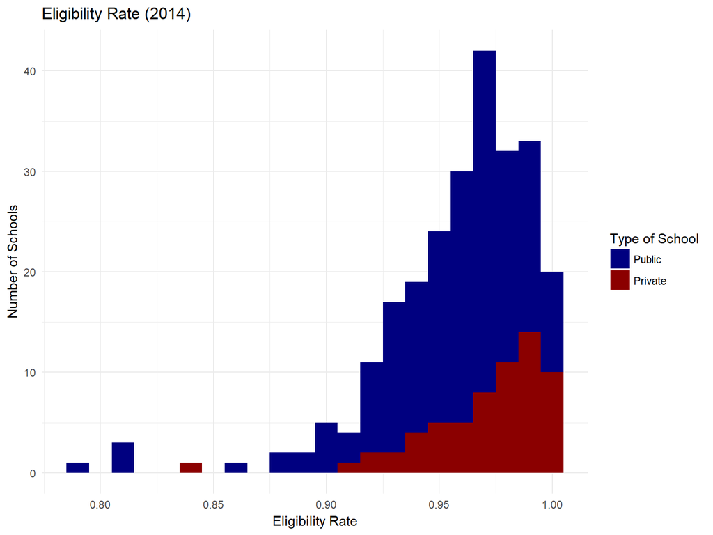

# Theme Arguments

Centering the title:

```r
plot1_centered <- plot1_colorchange + theme(plot.title = element_text(hjust = 0.5))
```

- The `hjust = 0.5` command indicates to center the title halfway between the left and right margins.

Moving the legend:

```r
plot1_legend_bottom <- plot1_centered + theme(legend.position = "bottom")
```

# Combining Multiple Theme Elements

We can technically combine both of these changes into a single `theme()` command:

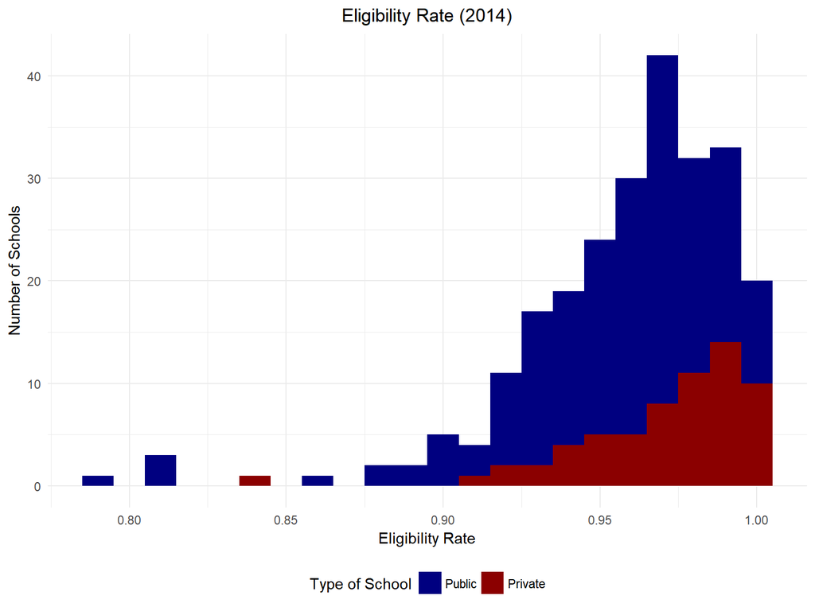

```r
plot1_final <- plot1_colorchange + theme(plot.title = element_text(hjust = 0.5),
    legend.position = "bottom")
print(plot1_final)
```

# Plotting by Group

ggplot2 includes two very powerful ways to `facet`, or produce a separate plot for each group (or a combination of groups). To produce a separate plot for each group, we use the `facet_wrap()` command:

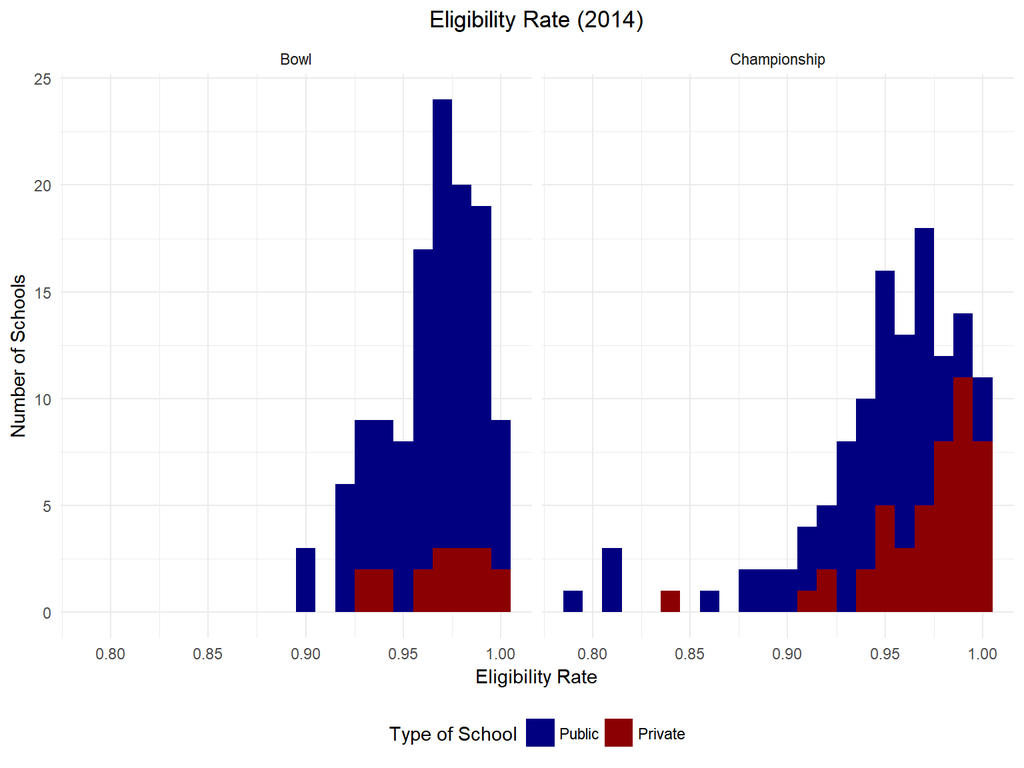

```r
facet_titles <- c(`1` = "Bowl", `2` = "Championship")
plot1_faceted <- plot1_final + facet_wrap(~as.factor(SUBDIVISION), labeller = labeller(.cols = facet_titles))
print(plot1_faceted)
```

# Plotting by Groups

We can also facet into a grid of plots at each combination of two variables:

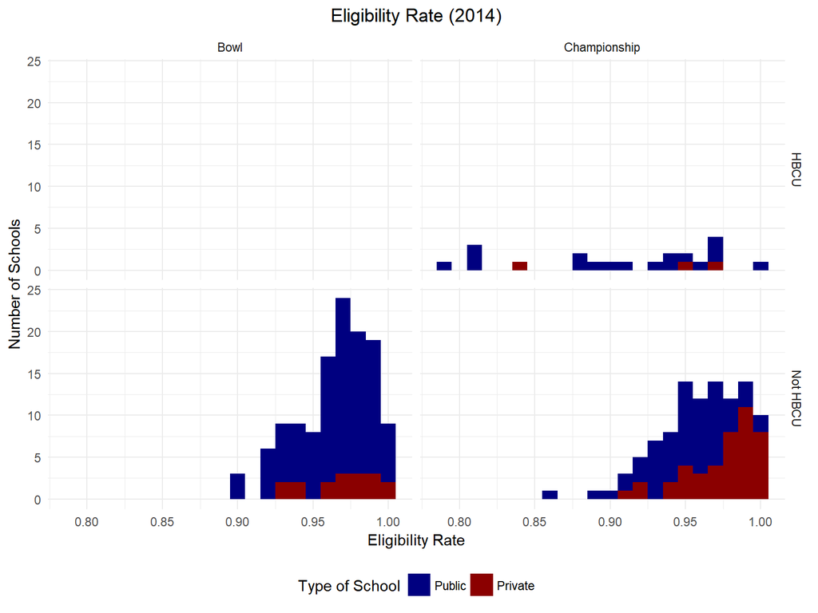

```r
row_titles <- c(`1` = "HBCU", `2` = "Not HBCU")
column_titles <- c(`1` = "Bowl", `2` = "Championship")
plot1_gridded <- plot1_final + facet_grid(as.factor(SCL_HBCU) ~ as.factor(SUBDIVISION),
    labeller = labeller(.rows = row_titles, .cols = column_titles))
print(plot1_gridded)
```

# Visualization Activity

We want to investigate how the relationship between eligibility rate and retention rate changes among the ten different Bowl Subdivision conferences.

Start off with this code:

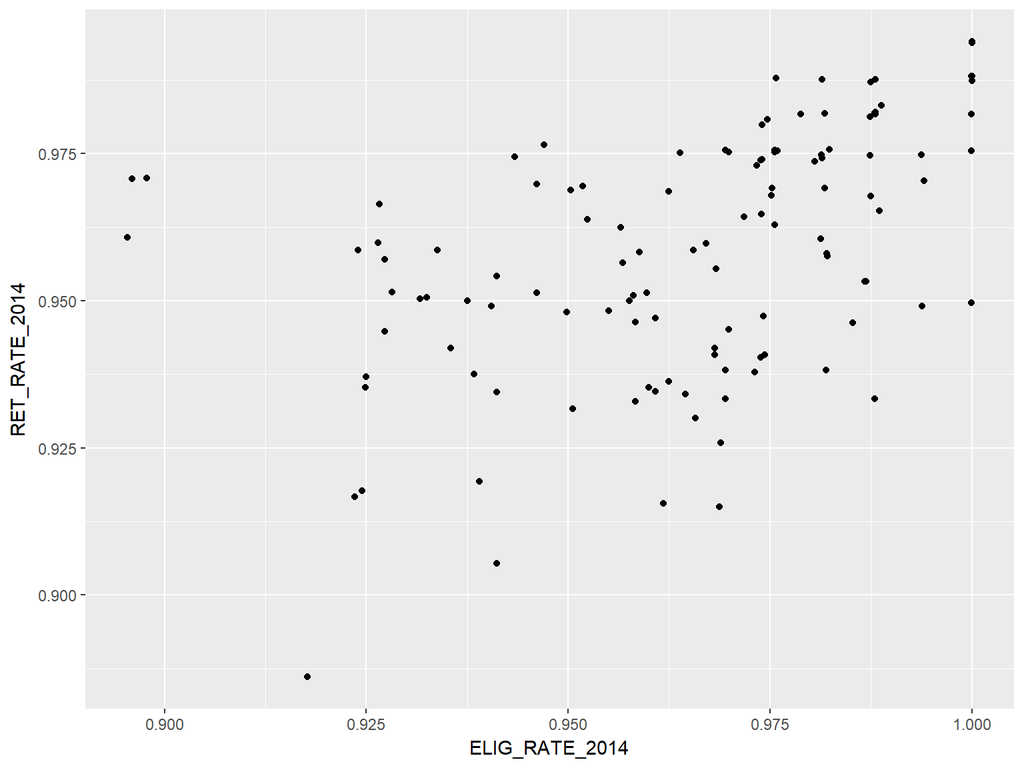

```r
FBS <- APR %>% filter(SUBDIVISION == 1, CONFERENCE != "Independent")
plot2 <- ggplot(data = FBS, mapping = aes(x = ELIG_RATE_2014, y = RET_RATE_2014)) +
    geom_jitter()
```

# Visualization Activity

Start off with this code:

```r
FBS <- APR %>% filter(SUBDIVISION == 1, CONFERENCE != "Independent")
plot2 <- ggplot(data = FBS, mapping = aes(x = ELIG_RATE_2014, y = RET_RATE_2014)) +
    geom_jitter()
```

And produce this plot:

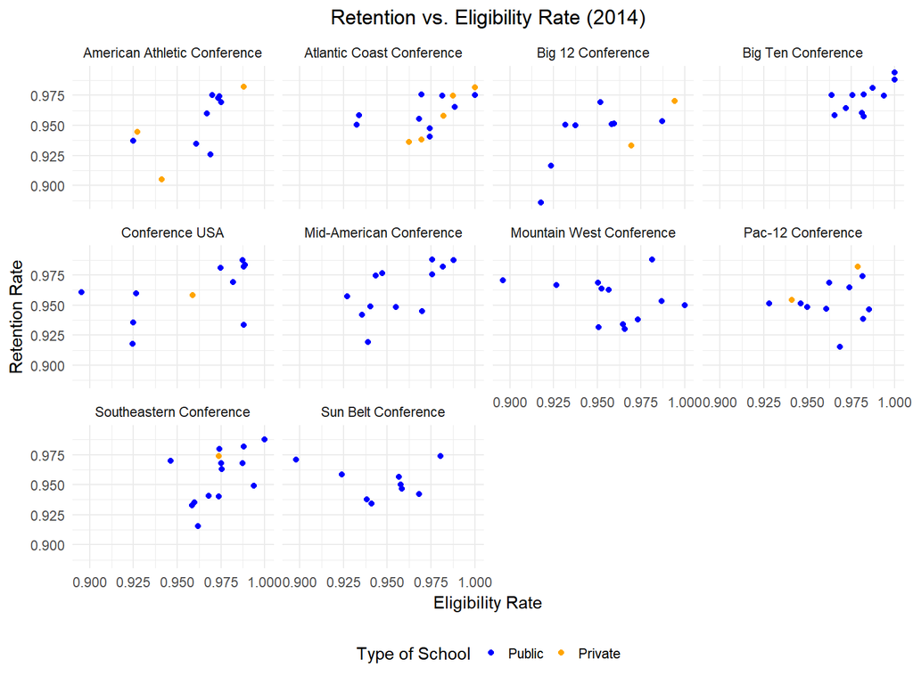

# Activity Hints

- You will need to start by including a `color =` argument in your `ggplot` command
- This means that you will use `scale_color_manual` to change your color scheme
- `geom_jitter()` produces a jittered scatterplot so that you can see points “on top” of each other
- You do not need to include a `labeller =` argument when you start faceting
- Think about whether you have one variable to facet by (`facet_wrap`) or two (`facet_grid`)

# Unsupervised Learning: Benefits and Challenges

- Often considered part of exploratory data analysis
- Learn about relationships between observations and between variables without an obvious “right” answer
- We have no way of checking whether our answer is good

# K-Means Clustering

- Simple method for finding subgroups in our observations that are similar with respect to a set of numerical variables
- Goal: assign each observation to one of k clusters such that:
  - Each observation is in exactly one cluster
  - The within-cluster variation is as small as possible
- In k-means clustering, we try to minimize the sum of squared distances (over all k clusters) between each observation in a cluster and the (multivariate) mean of the cluster

# Before We Start Clustering

- Any technique involving squared distance is extremely sensitive to scale
- Variables with a lot of variation will contribute much more to the sum of squared distances than variables with only a little bit
- We need to “standardize” or “scale” our values to remove this effect

```r
kmeans_2013_data <- APR %>% filter(ELIG_RATE_2013 > 0, RET_RATE_2013 > 0) %>%
    select(ELIG_RATE_2013, RET_RATE_2013)

# Scale variables
kmeans_2013_data_scaled <- scale(kmeans_2013_data)
```

# Reproducing Our Clusters

We start k-means clustering by randomly assigning data points. In order to reproduce our results, we will need to set a seed for R’s random number generation algorithm.

```r
set.seed(122)
```

Once we set a seed, we ensure that “random” numbers can be reliably reproduced. This is very important for replicating simulations!

# Randomly Assigning Clusters

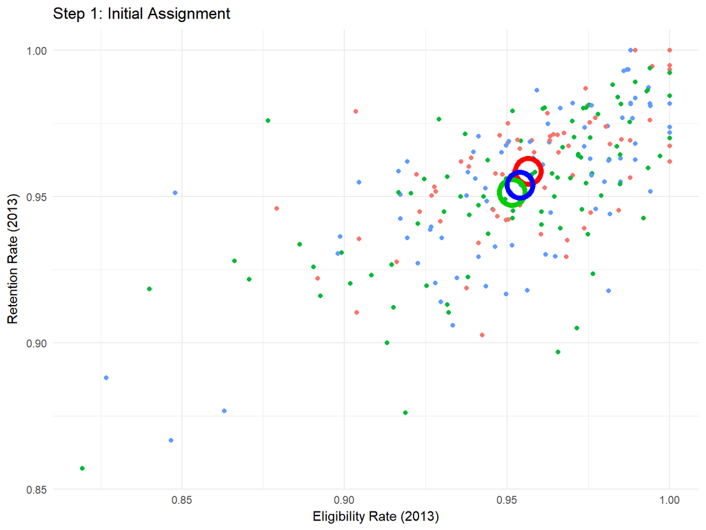

# Reassigning Clusters

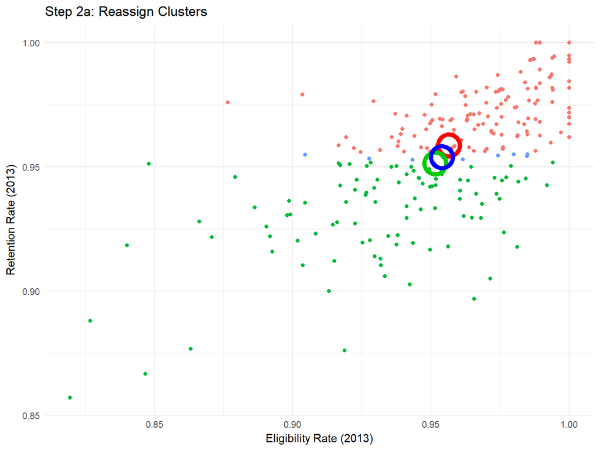

# Computing the New Means

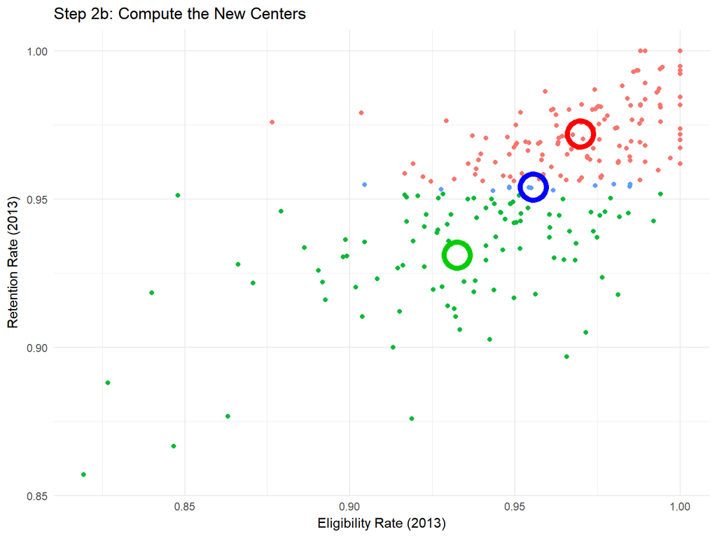

# Repeat Until Convergence

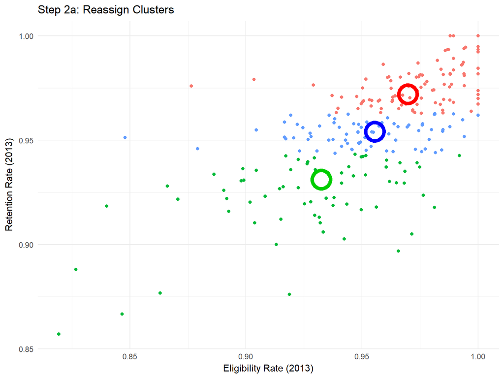

# Repeat Until Convergence

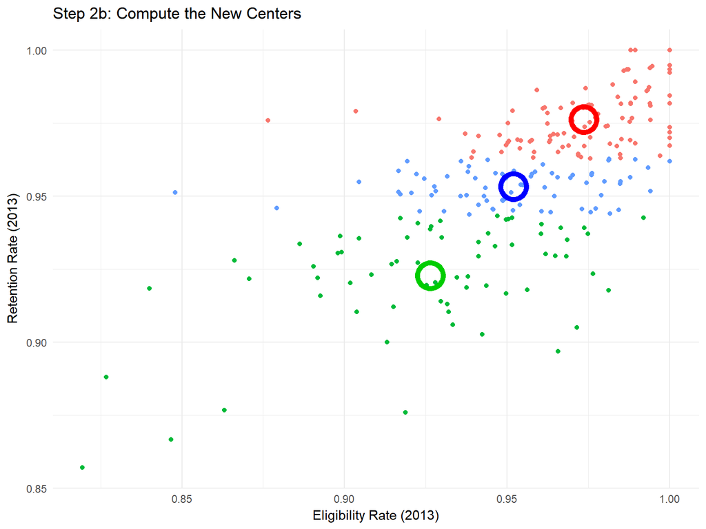

# When Points Stop Changing Clusters…

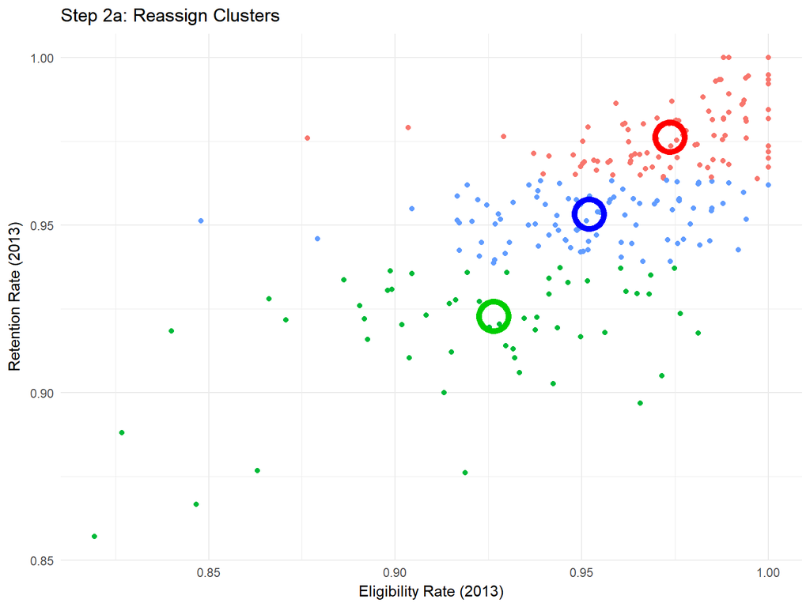

# …We Have Convergence

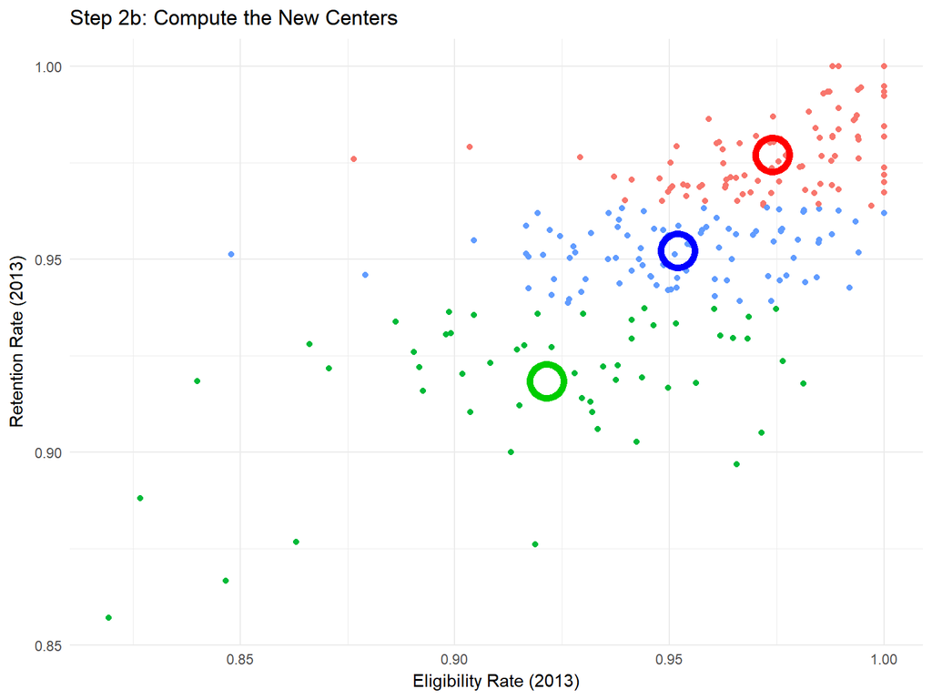

# Exploratory Data Analysis with K-Means

The R function `kmeans()` automatically creates clusters for you! It takes two arguments:

1. A data frame with only numerical variables, preferably scaled in advance
2. The number of clusters you want

You should store the results in a variable so that you can plot it later

Example code:

```r
# The centers argument indicates the number of clusters
kmeans_2 <- kmeans(kmeans_2013_data_scaled, centers = 5)
```

# Exploratory Data Analysis with K-Means

Once your clustering algorithm has run, you can get the cluster numbers out…

```r
# the as.factor() command indicates to make it a categorical variable
Cluster <- as.factor(kmeans_2$cluster)
```

…and add it to your original data frame

```r
# The cbind() command indicates to merge two data frames or vectors with the
# same number of rows/elements
km_final <- cbind(kmeans_2013_data, Cluster)
```

Now we can use `Cluster` in our ggplot commands to show the clusters:

```r
ggplot(km_final, aes(x = ELIG_RATE_2013, y = RET_RATE_2013, color = Cluster)) +
    geom_jitter()
```

# Exploratory Data Analysis with K-Means

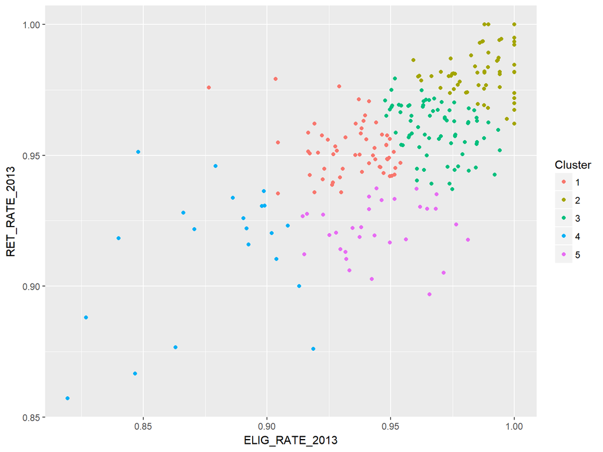

# K-Means Clustering: Activity

Let’s run a k-means clustering algorithm to divide our colleges into 3 groups based on the number of athletes and the APR in 2014. First we’ll get the data:

```r
# We have to do pre-processing to remove missing data
km_activity <- APR %>% select(NUM_OF_ATHLETES_2014, APR_2014) %>% filter(!is.na(NUM_OF_ATHLETES_2014))
```

1. Run a k-means clustering algorithm without scaling the data
2. Scale the data and then run a k-means clustering algorithm
3. Plot your results. How do the two results differ?
4. If you have time, play around with changing the number of centers

# Activity Solution: K-Means Code

```r
# Unscaled
km_unscaled <- kmeans(km_activity, centers = 3)
Cluster <- as.factor(km_unscaled$cluster)
km_final_unscaled <- cbind(km_activity, Cluster)

# Scaled
km_scaled_raw <- scale(km_activity)
km_scaled_cluster <- kmeans(km_scaled_raw, centers = 3)
Cluster <- as.factor(km_scaled_cluster$cluster)
km_final_scaled <- cbind(km_activity, Cluster)
```

# Activity Solution: Unscaled

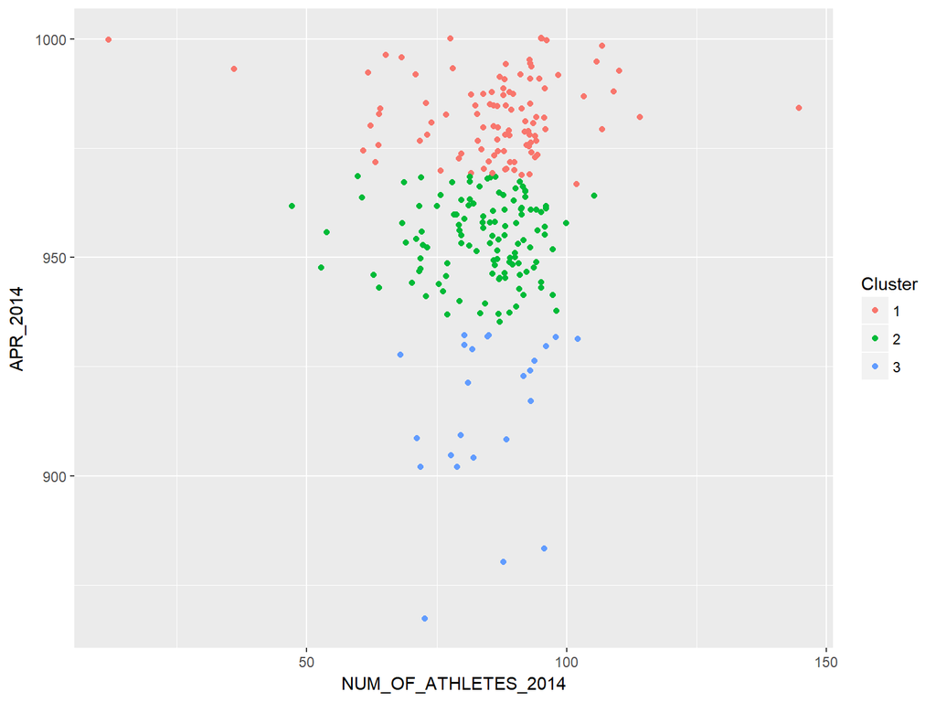

```r
ggplot(km_final_unscaled, aes(x = NUM_OF_ATHLETES_2014, y = APR_2014, color = Cluster)) +
    geom_jitter()
```

# Activity Solution: Scaled

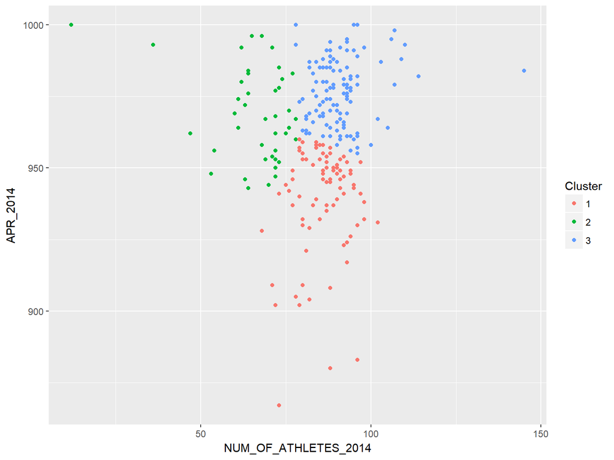

```r
ggplot(km_final_scaled, aes(x = NUM_OF_ATHLETES_2014, y = APR_2014, color = Cluster)) +
    geom_point()
```

# Activity Solution: Interpretation

- When we don’t scale, it looks like the only thing that matters is APR, and we can divide the colleges into those with high, medium, and low APR
- Because APR variability is much higher than variability in number of athletes, it dominates the clustering algorithm when we don’t scale
- When we scale, one group is still the “low APR” group, but now we have two different “high APR” groups: one with many athletes, and one with fewer athletes

# Resampling Techniques: Motivation

- Suppose we are interested in comparing the APR of public and private schools. We can think of the 2014 data as a representative sample of the APR that we could reasonably expect to measure in any given year.

```r
APR %>% group_by(SCL_PRIVATE) %>% summarize(count = n(), avg_APR = mean(APR_2014),
    sd_APR = sd(APR_2014))
```

```
## # A tibble: 2 × 4
##   SCL_PRIVATE count  avg_APR   sd_APR
##         <int> <int>    <dbl>    <dbl>
## 1           0   184 959.1033 22.89857
## 2           1    63 971.4286 20.56517
```

- How do we know whether this 12-point difference in APR between the private schools (`SCL_PRIVATE = 1`) and public schools (`SCL_PRIVATE = 0`) is significant?

# Resampling Techniques: Motivation

- In your stats class you may have learned about z-test, t-test, and other mean inference based on the Central Limit Theorem
- You probably had some sample size heuristic (n > 30) that said you were okay to do the test
- But here it is not so clear that we actually want to do inference about the mean
- Both groups are skewed left with some outliers, so the median may be the more informative measure of center

# Resampling Techniques: Motivation

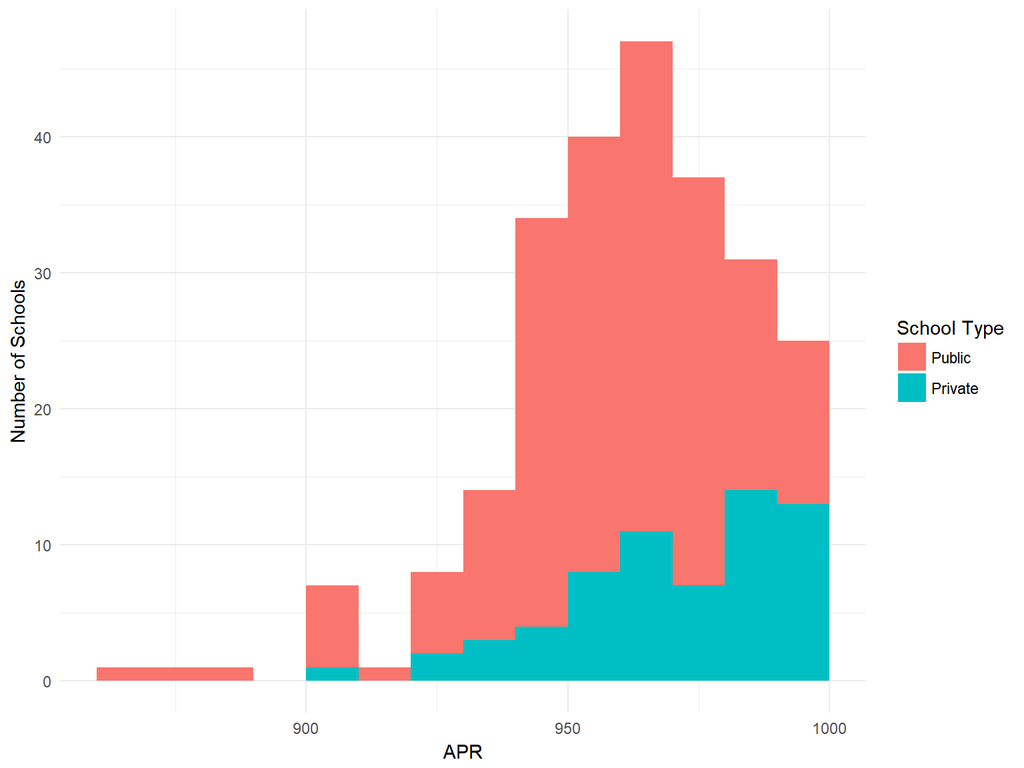

```r
ggplot(data = APR, aes(x = APR_2014, fill = as.factor(SCL_PRIVATE))) + geom_histogram(binwidth = 10,
    center = 5) + theme_minimal() + scale_fill_discrete(name = "School Type",
    labels = c("Public", "Private")) + labs(x = "APR", y = "Number of Schools")
```

# Resampling Techniques: Motivation

```r
APR %>% group_by(SCL_PRIVATE) %>% summarize(med_APR = median(APR_2014))
```

```
## # A tibble: 2 × 2
##   SCL_PRIVATE med_APR
##         <int>   <dbl>
## 1           0     961
## 2           1     977
```

- How do we test whether the 16-point difference in median between private schools (`SCL_PRIVATE = 1`) and public schools (`SCL_PRIVATE = 0`) is significant?

# Resampling Techniques: The Bootstrap

- We will create many “simulated” data sets by sampling with replacement from our own data
- We will compute the statistic(s) of interest in each simulated data set
- We will obtain a “bootstrap sampling distribution” of the statistic
- We do our learning by “pulling ourselves up by our own bootstraps”

# Resampling Techniques: The Bootstrap

- To perform the bootstrap, we first have to do some setup:

```r
B <- 10000  # the number of simulated data sets to create

# get the public and private schools
public_schools <- APR %>% filter(SCL_PRIVATE == 0)
private_schools <- APR %>% filter(SCL_PRIVATE == 1)

# get the number of each type of school
n_public <- nrow(public_schools)
n_private <- nrow(private_schools)

public_medians <- numeric(B)  # empty vector with B entries
private_medians <- numeric(B)

set.seed(1)  # set a seed for reproducibility
```

# Resampling Techniques: The Bootstrap

Now we will simulate `B` datasets from our original dataset, and obtain the median for each simulated dataset:

```r
for (i in 1:B) {
    # This is a 'for loop' and we run through it B times
    public_simulated <- sample(public_schools$APR_2014, size = n_public, replace = TRUE)
    private_simulated <- sample(private_schools$APR_2014, size = n_private,
        replace = TRUE)

    public_medians[i] <- median(public_simulated)
    private_medians[i] <- median(private_simulated)
}
```

# Resampling Techniques: The Bootstrap

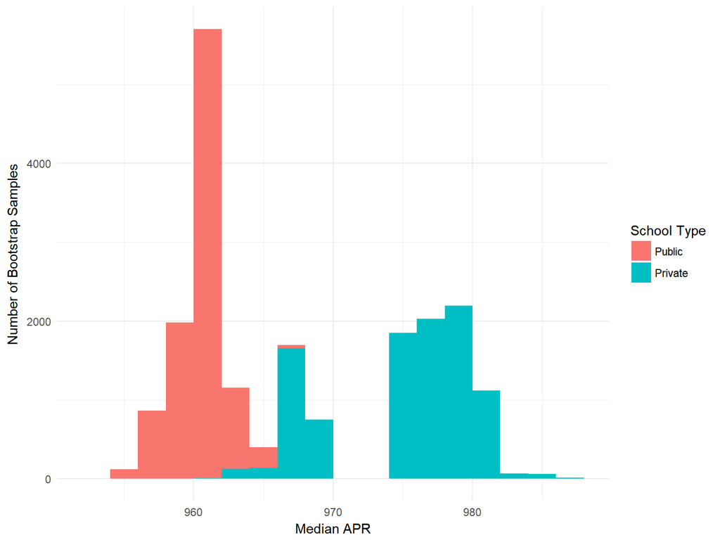

# Resampling Techniques: The Bootstrap

- What if we wanted a 95% Confidence Interval for the medians?
- Confidence is just an estimate of what proportion of the time (in the long run) the true population parameter will be in the interval
- We just simulated 10,000 datasets! That’s a “long enough” run for us to estimate with confidence!
- We estimate our confidence intervals by merely finding the middle 95% of medians
- This requires use of the `quantile()` function in R

# Resampling Techniques: The Bootstrap

```r
# Middle 95% means lower bound at 2.5% and upper bound at 97.5%
ci_public <- quantile(public_medians, c(0.025, 0.975))
ci_private <- quantile(private_medians, c(0.025, 0.975))

data.frame(Public = ci_public, Private = ci_private)
```

```
##       Public Private
## 2.5%   958.0     965
## 97.5%  964.5     982
```

Since the confidence bounds do not overlap, we suspect that (at least with 95% confidence) there is a difference in the median APR of Private vs. Public schools.

# Bootstrap: Activity

We wish to see if an equivalent difference in APR exists between “Bowl Subdivision” schools (typically larger athletic programs) and “Championship Subdivision” schools (smaller athletic programs).

Using the code in the previous slides as a template:

- Obtain a histogram of the APR rates for “Bowl Subdivision” football schools (`SUBDIVISION = 1`) vs. “Championship Subdivision” football schools (`SUBDIVISION = 2`)
- Obtain the sample median for each subdivision
- Obtain 10,000 bootstrap samples for each subdivision and compute the median
- Obtain 95% bootstrap confidence intervals for the median APR in each subdivision
- Interpret your results
- If you have time, try to make a histogram of your bootstrap samples. Is there any weirdness like we saw in the Public vs. Private example?

# Bootstrap Activity: Solution

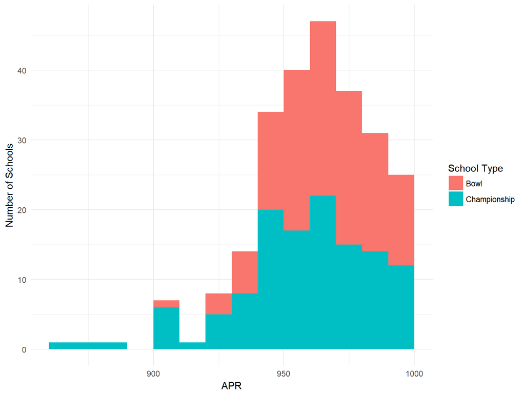

```r
ggplot(data = APR, aes(x = APR_2014, fill = as.factor(SUBDIVISION))) + geom_histogram(binwidth = 10,
    center = 5) + theme_minimal() + scale_fill_discrete(name = "School Type",
    labels = c("Bowl", "Championship")) + labs(x = "APR", y = "Number of Schools")
```

# Bootstrap Activity: Solution

```r
APR %>% group_by(SUBDIVISION) %>% summarize(num_schools = n(), avg_APR = mean(APR_2014),
    sd_APR = sd(APR_2014), med_APR = median(APR_2014))
```

```
## # A tibble: 2 × 5
##   SUBDIVISION num_schools  avg_APR   sd_APR med_APR
##         <int>       <int>    <dbl>    <dbl>   <dbl>
## 1           1         124 966.3387 18.26138   966.5
## 2           2         123 958.1220 26.25836   962.0
```

Now we set up the bootstrap:

```r
B <- 10000  # the number of simulated data sets to create

# get the two subdivisions
fbs_schools <- APR %>% filter(SUBDIVISION == 1)
fcs_schools <- APR %>% filter(SUBDIVISION == 2)

# get the number of each type of school
n_fbs <- nrow(fbs_schools)
n_fcs <- nrow(fcs_schools)

fbs_medians <- numeric(B)  # empty vector with B entries
fcs_medians <- numeric(B)

set.seed(2211)  # set a seed for reproducibility
```

# Bootstrap Activity: Solution

Now we simulate `B` datasets from our original data sets, and obtain the median for each dataset:

```r
for (i in 1:B) {
    # This is a 'for loop' and we run through it B times
    fbs_simulated <- sample(fbs_schools$APR_2014, size = n_fbs, replace = TRUE)
    fcs_simulated <- sample(fcs_schools$APR_2014, size = n_fcs, replace = TRUE)

    fbs_medians[i] <- median(fbs_simulated)
    fcs_medians[i] <- median(fcs_simulated)
}
```

# Bootstrap Activity: Solution

Now we obtain the 95% bootstrap confidence interval for each group:

```r
# Middle 95% means lower bound at 2.5% and upper bound at 97.5%
ci_fbs <- quantile(fbs_medians, c(0.025, 0.975))
ci_fcs <- quantile(fcs_medians, c(0.025, 0.975))

data.frame(Bowl = ci_fbs, Championship = ci_fcs)
```

```
##       Bowl Championship
## 2.5%   961          955
## 97.5%  972          967
```

Since the confidence bounds overlap, we do not suspect that (at least with 95% confidence) there is a difference in the median APR of Bowl vs. Championship Subdivision schools.

# Bootstrap Activity: Solution

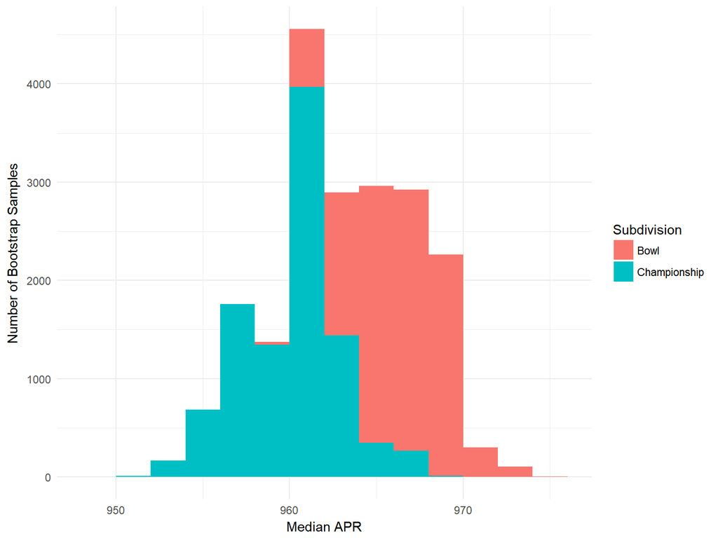

# Introduction to Supervised Learning

Recall from earlier, we asked the question:

- Which is more important to get right:
  - Explaining current observations?
  - Predicting future observations?

In supervised learning, we want to predict a specific response for future observations.

- How do we get future observations?

# Training - Validation - Test Set Model

We divide our data into three groups

- *Training* set: a subset of data, used to fit many different models
- *Validation* set: a subset of the training set, used to pick the “best” model
- *Test* set: everything other than the training set, used to test how well the “best” model predicts future observations

In many situations, you do not have a test set, only a validation set, so the validation set substitutes for the test set

# Training - Validation - Test Set Model: Evaluation

- We want to minimize error in the predictions of the test set
- Many different definitions of error
- Mean square error (MSE): average squared difference between actual and predicted response value
- Misclassification rate: proportion of observations classified in the “wrong” category
- MSE is popular for *regression* models and misclassification rate is popular for *classification* models
- Many variations on MSE and misclassification rate that penalize different types of errors differently

# Training - Validation - Test Set Model: Concerns

- *Data Leakage*: information in the training data allows the creation of models with unrealistically high accuracy
  - Incomplete separation of training and test data
  - “Future” information used to predict the “past”
  - Information the model should not have (for example, de-anonymized data)
- When leakage exists, the final model exploits a relationship that does not appear in the real world, making the model useless for predicting “real” future observations

# Single Validation Set Approach

- Randomly select observations in the training data set to set aside for validation
- How much you set aside typically depends on how big the data set is
- Problem: error is highly variable depending on which observations are set aside
- Problem: error tends to be overestimated because fewer observations are used
- Is there a way to “rotate” training and validation data so that we can use all observations in training and validation sets?

# Leave-One-Out Cross-Validation (LOOCV)

- Fit the model using every observation in the training set except one
- Obtain the error for the single observation left out
- Repeat until every observation has been left out exactly once
- Average the errors
- Advantage: every observation is set aside exactly once, so error is fixed for each model (and generally lower than for a single validation set)
- Problem: very slow when we have lots of data and lots of models
- Can we speed up the process?

# k-Fold Cross-Validation

- Divide the training set into *k* groups (typically k = 5 or k = 10)
- Fit the model using every group except one
- The last group is the validation set; obtain its error
- Repeat until all *k* groups have been used as the validation set exactly once
- Average the errors, weighted by number of observations in each group
- Compromise between the simplicity of the single validation set approach and the reduction in error from the LOOCV approach

# k-Fold Cross-Validation: Linear Regression

- Linear regression is a supervised learning technique
- We have one response (y) and one or more predictors (x)
- Most of our “usual” evaluation of linear regression evaluates the *fit* of the model on *observed* data
- We do not know how well the linear regression model predicts *new* data
- Too few predictors: we don’t have enough information to predict new data accurately
- Too many predictors: we are fitting randomness and our predictions on new data will be inaccurate
- k-Fold Cross-Validation allows us to determine which set of predictors produces the smallest validation error rate

# k-Fold Cross-Validation: Creating the Folds

- We want to predict the 2013 APR from the 2012 eligbility rate and retention rate
- We do not have a test set here, so we will use entire data set as a training set and use 10-fold validation to evaluate our linear regression models
- First we use the `filter` function to remove observations with missing data for those variables
- Next we divide the remaining observations into 10 groups

```r
training_data <- APR %>% filter(!is.na(APR_2013), !is.na(ELIG_RATE_2012), !is.na(RET_RATE_2012))

k <- 10

# assign rows to group numbers
fold_numbers <- as.numeric(cut(seq(1, nrow(training_data)), breaks = k))

# randomly permute the rows of the training data
set.seed(900)
training_randomized <- sample_frac(training_data)
```

- Now we have to go build our models

# Step 1: Plot Your Data!

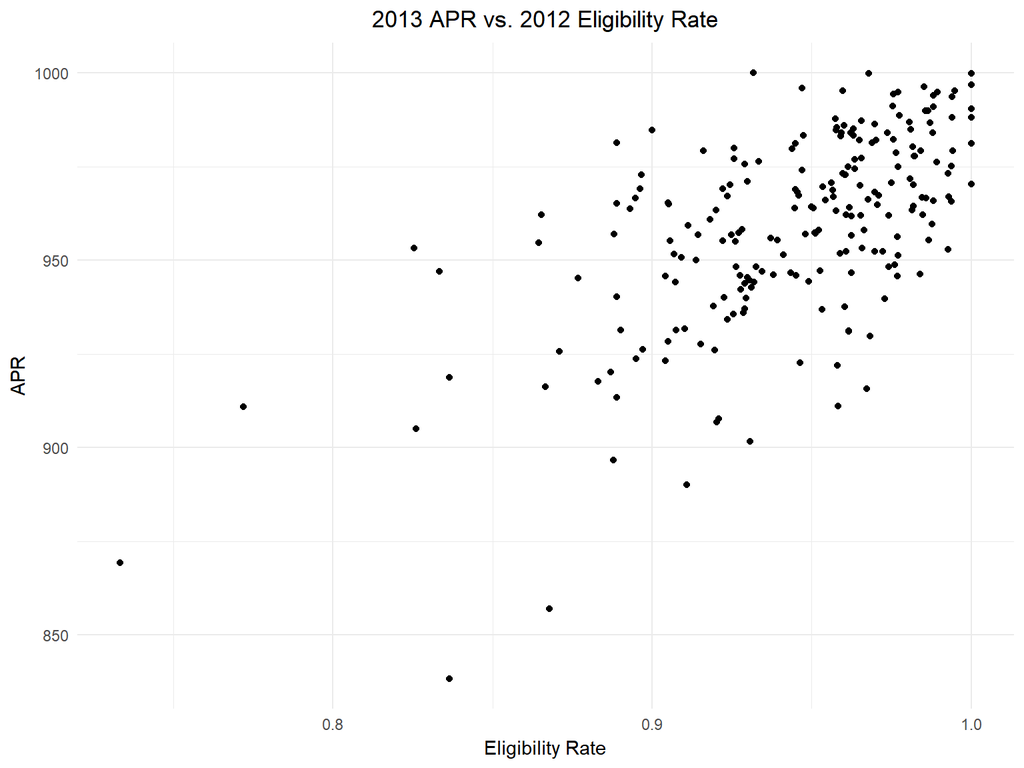

```r
# remove first fold as first validation set
training_1 <- training_randomized[fold_numbers != 1, ]
validation_1 <- training_randomized[fold_numbers == 1, ]

APR_plot1 <- ggplot(data = training_1, mapping = aes(x = ELIG_RATE_2012, y = APR_2013)) +
    geom_jitter() + labs(x = "Eligibility Rate", y = "APR", title = "2013 APR vs. 2012 Eligibility Rate") +
    theme_minimal() + theme(plot.title = element_text(hjust = 0.5))
print(APR_plot1)
```

# Step 1: Plot Your Data!

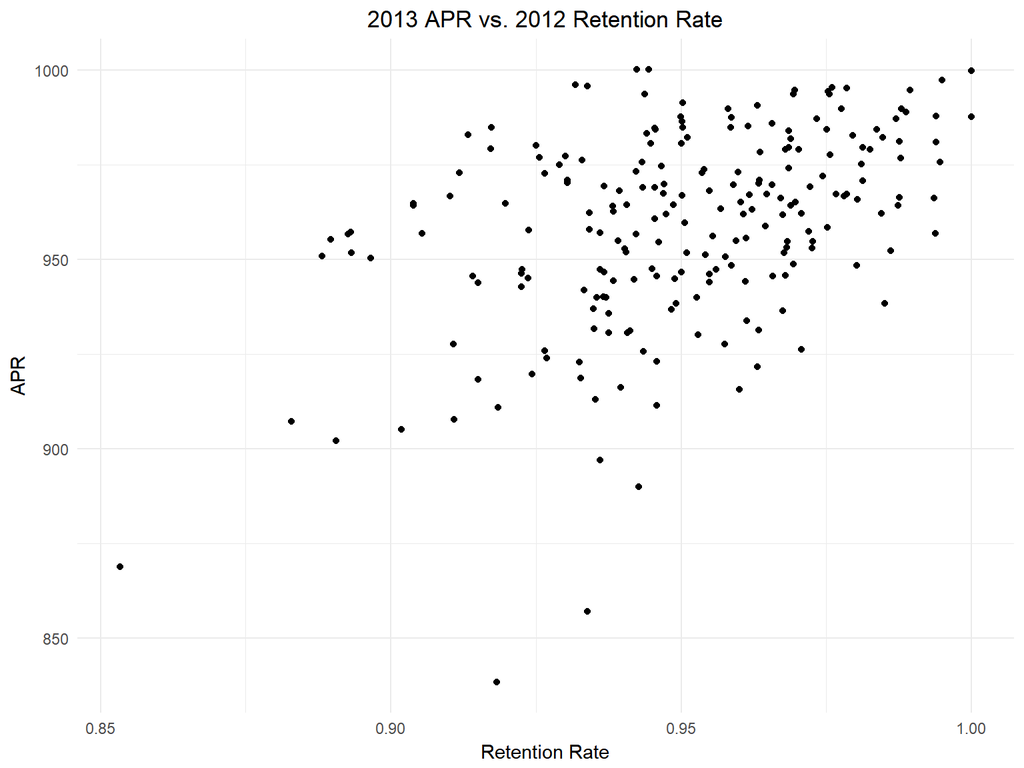

# Step 1: Plot Your Data!

- Ideally, you also make a scatterplot for each pair of predictors:

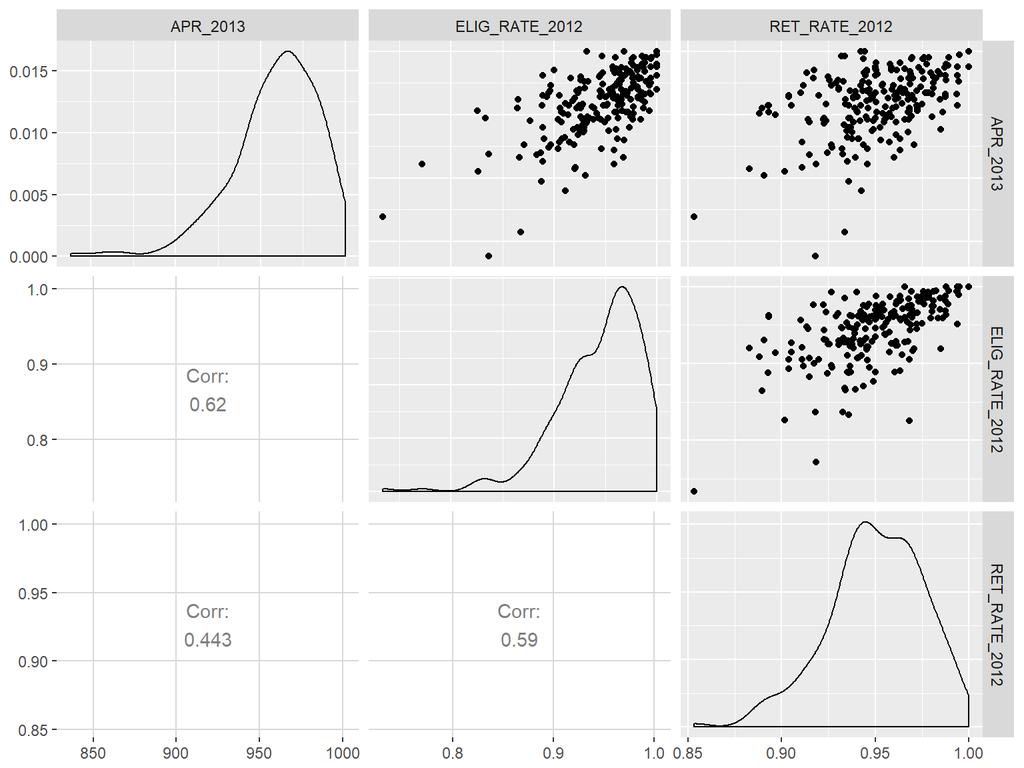

```r
library(GGally)
ggpairs(training_1, columns = c("APR_2013", "ELIG_RATE_2012", "RET_RATE_2012"),
    upper = list(continuous = "points"), lower = list(continuous = "cor"))
```

# Simple Linear Regression: Building a Model

- Formula: $Response \sim Predictor$
- Indicate where R should look to find those variables

```r
lm_EL <- lm(APR_2013 ~ ELIG_RATE_2012, data = training_1)
summary(lm_EL)
```

```
##
## Call:
## lm(formula = APR_2013 ~ ELIG_RATE_2012, data = training_1)
##
## Residuals:
##    Min     1Q Median     3Q    Max
## -79.22 -11.59   2.39  14.81  45.74
##
## Coefficients:
##                Estimate Std. Error t value Pr(>|t|)
## (Intercept)      591.77      31.59   18.73   <2e-16 ***
## ELIG_RATE_2012   389.07      33.44   11.64   <2e-16 ***
## ---
## Signif. codes:  0 '***' 0.001 '**' 0.01 '*' 0.05 '.' 0.1 ' ' 1
##
## Residual standard error: 20.4 on 217 degrees of freedom
## Multiple R-squared:  0.3842, Adjusted R-squared:  0.3814
## F-statistic: 135.4 on 1 and 217 DF,  p-value: < 2.2e-16
```

- Equation: $APR\_2013 = 591.77 + 389.07(ELIG\_RATE\_2012)$
- $R^2: 0.38$

# Simple Linear Regression: Interpretation

- Equation: $APR\_2013 = 591.77 + 389.07(ELIG\_RATE\_2012)$
- When Eligibility Rate is 0, we expect the 2013 APR to be 591.77
- Intercept interpretation may or may not be particularly interesting
- For a one-unit increase in Eligibility Rate, we expect the 2013 APR to increase by 389.07 points
- Slope interpretation may or may not be useful depending on the scale (our eligibility rate is on a scale of 0-1)
- We can rescale our variables to make these interpretations useful, but often don’t until we have selected our final model

# Multiple Linear Regression: Building a Model

- Formula: $Response \sim Predictor_1 + Predictor_2 + Predictor_3 + \ldots$

```r
lm_EL_RET <- lm(APR_2013 ~ ELIG_RATE_2012 + RET_RATE_2012, data = training_1)
summary(lm_EL_RET)
```

```
##
## Call:
## lm(formula = APR_2013 ~ ELIG_RATE_2012 + RET_RATE_2012, data = training_1)
##
## Residuals:
##     Min      1Q  Median      3Q     Max
## -80.090 -12.252   1.232  13.775  45.902
##
## Coefficients:
##                Estimate Std. Error t value Pr(>|t|)
## (Intercept)      519.29      51.00  10.182  < 2e-16 ***
## ELIG_RATE_2012   345.27      41.18   8.384 6.59e-15 ***
## RET_RATE_2012    119.78      66.39   1.804   0.0726 .
## ---
## Signif. codes:  0 '***' 0.001 '**' 0.01 '*' 0.05 '.' 0.1 ' ' 1
##
## Residual standard error: 20.3 on 216 degrees of freedom
## Multiple R-squared:  0.3934, Adjusted R-squared:  0.3877
## F-statistic: 70.03 on 2 and 216 DF,  p-value: < 2.2e-16
```

- Equation: $APR\_2013 = 519.29 + 345.27(ELIG\_RATE\_2012) + 119.78(RET\_RATE\_2012)$
- $R^2: 0.39$
- $R^2$ always goes up when we add more variables to a model

# Multiple Linear Regression: Interpretation

- Equation: $APR\_2013 = 519.29 + 345.27(ELIG\_RATE\_2012) + 119.78(RET\_RATE\_2012)$
- Intercept: When Eligibility Rate is 0 *and* Retention Rate is 0, we expect the 2013 APR to be 519.29
- Slope: For a one-unit increase in Eligibility Rate, we expect the 2013 APR to increase by 345.27 points, *holding the value of Retention Rate constant*.
- Slope: For a one-unit increase in Retention Rate, we expect the 2013 APR to increase by 119.78 points, *holding the value of Eligibility Rate constant*.
- In this model we assume that Eligibility Rate and Retention Rate independently affect APR

# Multiple Linear Regression: Interaction Effects

- Suppose we believe that the effect of Eligibility Rate on APR changes depending on the Retention Rate
- We include this *interaction effect* in our formula by replacing `+` with `*`:

```r
lm_interaction <- lm(APR_2013 ~ ELIG_RATE_2012 * RET_RATE_2012, data = training_1)
summary(lm_interaction)
```

```
##
## Call:
## lm(formula = APR_2013 ~ ELIG_RATE_2012 * RET_RATE_2012, data = training_1)
##
## Residuals:
##     Min      1Q  Median      3Q     Max
## -79.948 -12.196   1.094  13.987  45.808
##
## Coefficients:
##                              Estimate Std. Error t value Pr(>|t|)
## (Intercept)                     406.9      793.9   0.513    0.609
## ELIG_RATE_2012                  464.3      840.1   0.553    0.581
## RET_RATE_2012                   240.2      851.3   0.282    0.778
## ELIG_RATE_2012:RET_RATE_2012   -127.5      898.3  -0.142    0.887
##
## Residual standard error: 20.34 on 215 degrees of freedom
## Multiple R-squared:  0.3934, Adjusted R-squared:  0.3849
## F-statistic: 46.48 on 3 and 215 DF,  p-value: < 2.2e-16
```

- Equation: $APR\_2013 = 406.9 + 464.3(ELIG\_RATE\_2012) + 240.2(RET\_RATE\_2012) \\ - 127.5(ELIG\_RATE\_2012)(RET\_RATE\_2012)$

# Multiple Linear Regression: Interaction Effects

- Equation: $APR\_2013 = 406.9 + 464.3(ELIG\_RATE\_2012) + 240.2(RET\_RATE\_2012) \\ - 127.5(ELIG\_RATE\_2012)(RET\_RATE\_2012)$
- Slope: For a one-unit increase in Eligibility Rate, we expect the 2013 APR to increase by 464.3 points, *minus 127.5 times the Retention Rate*.
- Slope: For a one-unit increase in Retention Rate, we expect the 2013 APR to increase by 240.2 points, *minus 127.5 times the Eligibility Rate*.
- The effect of Eligibility Rate is *weaker* when Retention Rate is high, and the effect of Retention Rate is *weaker* when Eligibility Rate is high

# Linear Regression: Predicting New Data

```r
lm_EL_predictions <- predict(lm_EL, newdata = validation_1)
newdata_predictions <- data.frame(observed = validation_1$APR_2013, predicted = lm_EL_predictions)
head(newdata_predictions)
```

```
##   observed predicted
## 1      981  944.3646
## 2      974  968.2892
## 3      987  979.0217
## 4      948  950.4869
## 5      934  955.4658
## 6      927  960.3625
```

- We can also use the `predict()` function to do inference:
  - Confidence intervals for a mean response
  - Prediction intervals for an individual response

# Linear Regression: Mean Squared Error

- Average squared difference between the observed and predicted response values

```r
squared_residuals <- (validation_1$APR_2013 - lm_EL_predictions)^2
mse <- mean(squared_residuals)
print(mse)
```

```
## [1] 375.2216
```

- MSE is highly dependent on the scale of the response
- It can be directly compared between models because the response variable stays the same

# Linear Regression: k-Fold Cross-Validation

- Build a `for` loop that runs $k$ times
- Every time we go through the loop, we hold out one fold as our validation set, and fit each model on the rest of the data
- Then we predict the values of the validation set, given the best linear regression line for each set of model parameters
- Finally, we compute the mean squared error: average squared distance between the actual APR values and the predicted APR values
- After the `for` loop is done, we compute the weighted average of MSE across all 10 folds, for each model
- The best model is the model with lowest average MSE
- We end by fitting the best model on the entire data set, to get coefficient estimates

# Linear Regression: k-fold Cross-Validation

- We have five models:
  - One model with no predictors
  - Two models with one predictor
  - One model with both predictors but no interaction effect
  - One model with both predictors and an interaction effect
- Each time through the loop, we need to fit each model on the training set, and obtain the predictions on the validation set
- Each time through the loop, we need to record the number of observations in the validation set and the MSE of each model:

```r
# set up our evaluation variables
num_validation_observations <- numeric(k)
MSE_NULL <- numeric(k)
MSE_EL <- numeric(k)
MSE_RET <- numeric(k)
MSE_EL_RET <- numeric(k)
MSE_int <- numeric(k)
```

# k-Fold Cross-Validation: For Loop

```r
# write the for loop
for (i in 1:k) {
    training_set <- training_randomized[fold_numbers != i, ]
    validation_set <- training_randomized[fold_numbers == i, ]

    # Fit each model here
    lm_NULL <- lm(APR_2013 ~ 1, data = training_set)
    lm_EL <- lm(APR_2013 ~ ELIG_RATE_2012, data = training_set)
    lm_RET <- lm(APR_2013 ~ RET_RATE_2012, data = training_set)
    lm_EL_RET <- lm(APR_2013 ~ ELIG_RATE_2012 + RET_RATE_2012, data = training_set)
    lm_int <- lm(APR_2013 ~ ELIG_RATE_2012 * RET_RATE_2012, data = training_set)

    # Predictions go here
    pred_NULL <- predict(lm_NULL, newdata = validation_set)
    pred_EL <- predict(lm_EL, newdata = validation_set)
    pred_RET <- predict(lm_RET, newdata = validation_set)
    pred_EL_RET <- predict(lm_EL_RET, newdata = validation_set)
    pred_int <- predict(lm_int, newdata = validation_set)

    MSE_NULL[i] <- mean((validation_set$APR_2013 - pred_NULL)^2)
    MSE_EL[i] <- mean((validation_set$APR_2013 - pred_EL)^2)
    MSE_RET[i] <- mean((validation_set$APR_2013 - pred_RET)^2)
    MSE_EL_RET[i] <- mean((validation_set$APR_2013 - pred_EL_RET)^2)
    MSE_int[i] <- mean((validation_set$APR_2013 - pred_int)^2)

    num_validation_observations[i] <- nrow(validation_set)
}
```

# Linear Regression: Model Selection

```r
MSE_NULL_total <- sum(MSE_NULL * num_validation_observations)/sum(num_validation_observations)
MSE_EL_total <- sum(MSE_EL * num_validation_observations)/sum(num_validation_observations)
MSE_RET_total <- sum(MSE_RET * num_validation_observations)/sum(num_validation_observations)
MSE_EL_RET_total <- sum(MSE_EL_RET * num_validation_observations)/sum(num_validation_observations)
MSE_int_total <- sum(MSE_int * num_validation_observations)/sum(num_validation_observations)
print(c(MSE_NULL_total, MSE_EL_total, MSE_RET_total, MSE_EL_RET_total, MSE_int_total))
```

```
## [1] 658.6399 413.8099 533.0370 409.6381 412.1156
```

- Model with no predictors is the worst
- Model with eligibility rate and retention rate, but no interaction term, is the best

# Linear Regression: Final Model

- We select the model without the interaction term as our final model

```r
lm_final <- lm(APR_2013 ~ ELIG_RATE_2012 + RET_RATE_2012, data = training_data)
summary(lm_final)
```

```
##
## Call:
## lm(formula = APR_2013 ~ ELIG_RATE_2012 + RET_RATE_2012, data = training_data)
##
## Residuals:
##     Min      1Q  Median      3Q     Max
## -79.788 -12.085   1.219  13.974  46.178
##
## Coefficients:
##                Estimate Std. Error t value Pr(>|t|)
## (Intercept)      517.70      49.05  10.556  < 2e-16 ***
## ELIG_RATE_2012   345.13      39.74   8.685 5.85e-16 ***
## RET_RATE_2012    121.31      63.79   1.902   0.0584 .
## ---
## Signif. codes:  0 '***' 0.001 '**' 0.01 '*' 0.05 '.' 0.1 ' ' 1
##
## Residual standard error: 20.19 on 241 degrees of freedom
## Multiple R-squared:  0.3852, Adjusted R-squared:  0.3801
## F-statistic: 75.51 on 2 and 241 DF,  p-value: < 2.2e-16
```

- $APR\_2013 = 517.70 + 345.13(ELIG\_RATE\_2012) + 121.31(RET\_RATE\_2012)$

# Linear Regression: Activity

- Now we want to predict the 2014 APR from the 2013 statistics
- Remove the observations with missing data for the 2014 APR and 2013 retention rate and elgibility rate
- Divide your data set into 5 folds to use a five-fold cross-validation approach
- Create the five models using combinations of retention rate and eligibility rate
- Which model has the lowest MSE according to the cross-validation approach? Did the same model work to predict APR in 2013 and in 2014, or did we get a different model for 2014?

# Linear Regression: Activity Solutions

```r
training_data <- APR %>% filter(!is.na(APR_2014), !is.na(ELIG_RATE_2013), !is.na(RET_RATE_2013))

k <- 5

# assign rows to group numbers
fold_numbers <- as.numeric(cut(seq(1, nrow(training_data)), breaks = k))

# randomly permute the rows of the training data
set.seed(9200)
training_randomized <- sample_frac(training_data)

num_validation_observations <- numeric(k)
MSE_NULL <- numeric(k)
MSE_EL <- numeric(k)
MSE_RET <- numeric(k)
MSE_EL_RET <- numeric(k)
MSE_int <- numeric(k)
```

# Linear Regression: Activity Solutions

```r
# write the for loop
for (i in 1:k) {
    training_set <- training_randomized[fold_numbers != i, ]
    validation_set <- training_randomized[fold_numbers == i, ]

    # Fit each model here
    lm_NULL <- lm(APR_2014 ~ 1, data = training_set)
    lm_EL <- lm(APR_2014 ~ ELIG_RATE_2013, data = training_set)
    lm_RET <- lm(APR_2014 ~ RET_RATE_2013, data = training_set)
    lm_EL_RET <- lm(APR_2014 ~ ELIG_RATE_2013 + RET_RATE_2013, data = training_set)
    lm_int <- lm(APR_2014 ~ ELIG_RATE_2013 * RET_RATE_2013, data = training_set)

    # Predictions go here
    pred_NULL <- predict(lm_NULL, newdata = validation_set)
    pred_EL <- predict(lm_EL, newdata = validation_set)
    pred_RET <- predict(lm_RET, newdata = validation_set)
    pred_EL_RET <- predict(lm_EL_RET, newdata = validation_set)
    pred_int <- predict(lm_int, newdata = validation_set)

    MSE_NULL[i] <- mean((validation_set$APR_2013 - pred_NULL)^2)
    MSE_EL[i] <- mean((validation_set$APR_2013 - pred_EL)^2)
    MSE_RET[i] <- mean((validation_set$APR_2013 - pred_RET)^2)
    MSE_EL_RET[i] <- mean((validation_set$APR_2013 - pred_EL_RET)^2)
    MSE_int[i] <- mean((validation_set$APR_2013 - pred_int)^2)

    num_validation_observations[i] <- nrow(validation_set)
}
```

# Linear Regression: Activity Solutions

```r
MSE_NULL_total <- sum(MSE_NULL * num_validation_observations)/sum(num_validation_observations)
MSE_EL_total <- sum(MSE_EL * num_validation_observations)/sum(num_validation_observations)
MSE_RET_total <- sum(MSE_RET * num_validation_observations)/sum(num_validation_observations)
MSE_EL_RET_total <- sum(MSE_EL_RET * num_validation_observations)/sum(num_validation_observations)
MSE_int_total <- sum(MSE_int * num_validation_observations)/sum(num_validation_observations)
print(c(MSE_NULL_total, MSE_EL_total, MSE_RET_total, MSE_EL_RET_total, MSE_int_total))
```

```
## [1] 665.2700 240.7587 345.6873 215.5759 227.5361
```

# Linear Regression: Activity Solutions

```r
lm_final <- lm(APR_2014 ~ ELIG_RATE_2013 + RET_RATE_2013, data = training_data)
summary(lm_final)
```

```
##
## Call:
## lm(formula = APR_2014 ~ ELIG_RATE_2013 + RET_RATE_2013, data = training_data)
##
## Residuals:
##     Min      1Q  Median      3Q     Max
## -86.836 -11.968   2.325  13.511  46.232
##
## Coefficients:
##                Estimate Std. Error t value Pr(>|t|)
## (Intercept)      569.84      47.69  11.949  < 2e-16 ***
## ELIG_RATE_2013   321.16      48.48   6.624 2.26e-10 ***
## RET_RATE_2013     90.26      66.18   1.364    0.174
## ---
## Signif. codes:  0 '***' 0.001 '**' 0.01 '*' 0.05 '.' 0.1 ' ' 1
##
## Residual standard error: 19.2 on 241 degrees of freedom
## Multiple R-squared:  0.2977, Adjusted R-squared:  0.2919
## F-statistic: 51.08 on 2 and 241 DF,  p-value: < 2.2e-16
```

- $APR\_2014 = 569.84 + 321.16(ELIG\_RATE\_2013) + 90.26(RET\_RATE\_2013)$

# What’s Next?

If you enjoyed this workshop, I highly recommend two books on which much of this workshop was based:

- Wickham and Grolemund, *R for Data Science*
- James, Witten, Hastie, and Tibshirani, *An Introduction to Statistical Learning with Applications in R*

Both sets of authors have made an eBook version freely available

# What’s Next?

- There are a lot more topics involved in statistical learning:
  - Classification algorithms
  - Dimensionality reduction and automatic feature selection
  - Combining bootstrap with regression/classification algorithms
  - Including non-numeric data in algorithms
- Stay tuned for workshops through CCAM and UEE covering more statistical learning!